# File d’attente M/G/1

Arnaud Legrand

1/28/2022

```r
set.seed(45) # Just to make the following computations deterministic and reproducible
```

# 1 A short introduction to R and ggplot

## 1.1 R basis

Vectors in R are cool. Here are a few examples of how to build and manipulate them. See, no need for `for` loops.

```r
x=c(1:5, -12, 17, seq(from=-3, to=8, by = 1.7))
x>3
```

```
##  [1] FALSE FALSE FALSE  TRUE  TRUE FALSE  TRUE FALSE FALSE FALSE FALSE  TRUE
## [13]  TRUE  TRUE
```

```r
x[x>3]
```

```
## [1]  4.0  5.0 17.0  3.8  5.5  7.2
```

```r
which(x>3)
```

```
## [1]  4  5  7 12 13 14
```

```r
5 %in% x
```

```
## [1] TRUE
```

```r
log(x^2)+4
```

```
##  [1] 4.000000 5.386294 6.197225 6.772589 7.218876 8.969813 9.666427 6.197225
##  [9] 4.524729 2.167419 5.483875 6.670002 7.409496 7.948162
```

Data frames are even cooler. First a few useful functions to inspect a data frame:

```r
names(mtcars)
```

```
##  [1] "mpg"  "cyl"  "disp" "hp"   "drat" "wt"   "qsec" "vs"   "am"   "gear"
## [11] "carb"
```

```r
str(mtcars)
```

```
## 'data.frame':    32 obs. of  11 variables:
##  $ mpg : num  21 21 22.8 21.4 18.7 18.1 14.3 24.4 22.8 19.2 ...
##  $ cyl : num  6 6 4 6 8 6 8 4 4 6 ...
##  $ disp: num  160 160 108 258 360 ...
##  $ hp  : num  110 110 93 110 175 105 245 62 95 123 ...
##  $ drat: num  3.9 3.9 3.85 3.08 3.15 2.76 3.21 3.69 3.92 3.92 ...
##  $ wt  : num  2.62 2.88 2.32 3.21 3.44 ...
##  $ qsec: num  16.5 17 18.6 19.4 17 ...
##  $ vs  : num  0 0 1 1 0 1 0 1 1 1 ...
##  $ am  : num  1 1 1 0 0 0 0 0 0 0 ...
##  $ gear: num  4 4 4 3 3 3 3 4 4 4 ...
##  $ carb: num  4 4 1 1 2 1 4 2 2 4 ...
```

```r
summary(mtcars)
```

```
##       mpg             cyl             disp             hp
##  Min.   :10.40   Min.   :4.000   Min.   : 71.1   Min.   : 52.0
##  1st Qu.:15.43   1st Qu.:4.000   1st Qu.:120.8   1st Qu.: 96.5
##  Median :19.20   Median :6.000   Median :196.3   Median :123.0
##  Mean   :20.09   Mean   :6.188   Mean   :230.7   Mean   :146.7
##  3rd Qu.:22.80   3rd Qu.:8.000   3rd Qu.:326.0   3rd Qu.:180.0
##  Max.   :33.90   Max.   :8.000   Max.   :472.0   Max.   :335.0
##       drat             wt             qsec             vs
##  Min.   :2.760   Min.   :1.513   Min.   :14.50   Min.   :0.0000
##  1st Qu.:3.080   1st Qu.:2.581   1st Qu.:16.89   1st Qu.:0.0000
##  Median :3.695   Median :3.325   Median :17.71   Median :0.0000
##  Mean   :3.597   Mean   :3.217   Mean   :17.85   Mean   :0.4375
##  3rd Qu.:3.920   3rd Qu.:3.610   3rd Qu.:18.90   3rd Qu.:1.0000
##  Max.   :4.930   Max.   :5.424   Max.   :22.90   Max.   :1.0000
##        am              gear            carb
##  Min.   :0.0000   Min.   :3.000   Min.   :1.000
##  1st Qu.:0.0000   1st Qu.:3.000   1st Qu.:2.000
##  Median :0.0000   Median :4.000   Median :2.000
##  Mean   :0.4062   Mean   :3.688   Mean   :2.812
##  3rd Qu.:1.0000   3rd Qu.:4.000   3rd Qu.:4.000
##  Max.   :1.0000   Max.   :5.000   Max.   :8.000
```

```r
dim(mtcars)
```

```
## [1] 32 11
```

```r
nrow(mtcars)
```

```
## [1] 32
```

```r
ncol(mtcars)
```

```
## [1] 11
```

Then a few useful functions to build one:

```r
df = data.frame() # empty data frame
N = 4
df1 = data.frame(x=1:N, y=rnorm(n = N), z = runif(n = N), t = c(TRUE,FALSE), val = "A")
df2 = data.frame(x=1:N, y=rnorm(n = N), z = runif(n = N), t = c(TRUE,FALSE), val = "B")
df = rbind(df1,df2)
df
```

```
##   x          y          z     t val
## 1 1  0.3407997 0.18456417  TRUE   A
## 2 2 -0.7033403 0.00528478 FALSE   A
## 3 3 -0.3795377 0.36889020  TRUE   A
## 4 4 -0.7460474 0.88046449 FALSE   A
## 5 1 -0.5013782 0.12915002  TRUE   B
## 6 2 -0.1745357 0.31987266 FALSE   B
## 7 3  1.8090374 0.58550179  TRUE   B
## 8 4 -0.2301050 0.66214577 FALSE   B
```

And finally a few examples of how to manipulate them:

```r
mtcars$cyl = as.factor(mtcars$cyl) # Making sur the type of your data is correct is in general a good idea
str(mtcars$cyl)
```

```
##  Factor w/ 3 levels "4","6","8": 2 2 1 2 3 2 3 1 1 2 ...
```

```r
mtcars$val = sqrt(mtcars$mpg + mtcars$qsec) # adding a new column
# 3 different ways to access the same data, which one do you prefer ?
mtcars[3,5]
```

```
## [1] 3.85
```

```r
mtcars[3,"drat"]
```

```
## [1] 3.85
```

```r
mtcars$drat[3]
```

```
## [1] 3.85
```

```r
# 2 different ways to extract particular rows and columns
mtcars[mtcars$cyl==4,names(mtcars) %in% c("hp","mpg","cyl")]
```

```
##                 mpg cyl  hp
## Datsun 710     22.8   4  93
## Merc 240D      24.4   4  62
## Merc 230       22.8   4  95
## Fiat 128       32.4   4  66
## Honda Civic    30.4   4  52
## Toyota Corolla 33.9   4  65
## Toyota Corona  21.5   4  97
## Fiat X1-9      27.3   4  66
## Porsche 914-2  26.0   4  91
## Lotus Europa   30.4   4 113
## Volvo 142E     21.4   4 109
```

```r
mtcars[mtcars$cyl==4,c("hp","mpg","cyl")]
```

```
##                 hp  mpg cyl
## Datsun 710      93 22.8   4
## Merc 240D       62 24.4   4
## Merc 230        95 22.8   4
## Fiat 128        66 32.4   4
## Honda Civic     52 30.4   4
## Toyota Corolla  65 33.9   4
## Toyota Corona   97 21.5   4
## Fiat X1-9       66 27.3   4
## Porsche 914-2   91 26.0   4
## Lotus Europa   113 30.4   4
## Volvo 142E     109 21.4   4
```

## 1.2 A short introduction to ggplot

For a short step-by-step introduction, you may like: https://evamaerey.github.io/ggplot_flipbook/ggplot_flipbook_xaringan.html#1

```r
mtcars
```

```
##                      mpg cyl  disp  hp drat    wt  qsec vs am gear carb
## Mazda RX4           21.0   6 160.0 110 3.90 2.620 16.46  0  1    4    4
## Mazda RX4 Wag       21.0   6 160.0 110 3.90 2.875 17.02  0  1    4    4
## Datsun 710          22.8   4 108.0  93 3.85 2.320 18.61  1  1    4    1
## Hornet 4 Drive      21.4   6 258.0 110 3.08 3.215 19.44  1  0    3    1
## Hornet Sportabout   18.7   8 360.0 175 3.15 3.440 17.02  0  0    3    2
## Valiant             18.1   6 225.0 105 2.76 3.460 20.22  1  0    3    1
## Duster 360          14.3   8 360.0 245 3.21 3.570 15.84  0  0    3    4
## Merc 240D           24.4   4 146.7  62 3.69 3.190 20.00  1  0    4    2
## Merc 230            22.8   4 140.8  95 3.92 3.150 22.90  1  0    4    2
## Merc 280            19.2   6 167.6 123 3.92 3.440 18.30  1  0    4    4
## Merc 280C           17.8   6 167.6 123 3.92 3.440 18.90  1  0    4    4
## Merc 450SE          16.4   8 275.8 180 3.07 4.070 17.40  0  0    3    3
## Merc 450SL          17.3   8 275.8 180 3.07 3.730 17.60  0  0    3    3
## Merc 450SLC         15.2   8 275.8 180 3.07 3.780 18.00  0  0    3    3
## Cadillac Fleetwood  10.4   8 472.0 205 2.93 5.250 17.98  0  0    3    4
## Lincoln Continental 10.4   8 460.0 215 3.00 5.424 17.82  0  0    3    4
## Chrysler Imperial   14.7   8 440.0 230 3.23 5.345 17.42  0  0    3    4
## Fiat 128            32.4   4  78.7  66 4.08 2.200 19.47  1  1    4    1
## Honda Civic         30.4   4  75.7  52 4.93 1.615 18.52  1  1    4    2
## Toyota Corolla      33.9   4  71.1  65 4.22 1.835 19.90  1  1    4    1
## Toyota Corona       21.5   4 120.1  97 3.70 2.465 20.01  1  0    3    1
## Dodge Challenger    15.5   8 318.0 150 2.76 3.520 16.87  0  0    3    2
## AMC Javelin         15.2   8 304.0 150 3.15 3.435 17.30  0  0    3    2
## Camaro Z28          13.3   8 350.0 245 3.73 3.840 15.41  0  0    3    4
## Pontiac Firebird    19.2   8 400.0 175 3.08 3.845 17.05  0  0    3    2
## Fiat X1-9           27.3   4  79.0  66 4.08 1.935 18.90  1  1    4    1
## Porsche 914-2       26.0   4 120.3  91 4.43 2.140 16.70  0  1    5    2
## Lotus Europa        30.4   4  95.1 113 3.77 1.513 16.90  1  1    5    2
## Ford Pantera L      15.8   8 351.0 264 4.22 3.170 14.50  0  1    5    4
## Ferrari Dino        19.7   6 145.0 175 3.62 2.770 15.50  0  1    5    6
## Maserati Bora       15.0   8 301.0 335 3.54 3.570 14.60  0  1    5    8
## Volvo 142E          21.4   4 121.0 109 4.11 2.780 18.60  1  1    4    2
##                          val
## Mazda RX4           6.120457
## Mazda RX4 Wag       6.166036
## Datsun 710          6.435060
## Hornet 4 Drive      6.390618
## Hornet Sportabout   5.976621
## Valiant             6.190315
```

[output cut: 11 more lines]

```
## Fiat 128            7.202083
## Honda Civic         6.994283
## Toyota Corolla      7.334848
## Toyota Corona       6.442825
## Dodge Challenger    5.689464
## AMC Javelin         5.700877
## Camaro Z28          5.358171
## Pontiac Firebird    6.020797
## Fiat X1-9           6.797058
## Porsche 914-2       6.534524
## Lotus Europa        6.877500
## Ford Pantera L      5.504544
## Ferrari Dino        5.932959
## Maserati Bora       5.440588
## Volvo 142E          6.324555
```

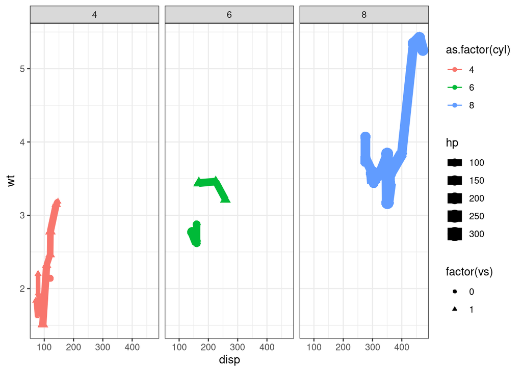

```r
library(ggplot2)
ggplot(data = mtcars, aes(x = disp, y = wt, color = as.factor(cyl),
                                 size = hp, shape = factor(vs))) + geom_point() + theme_bw() +
    geom_line() + facet_wrap(~as.factor(cyl))
```

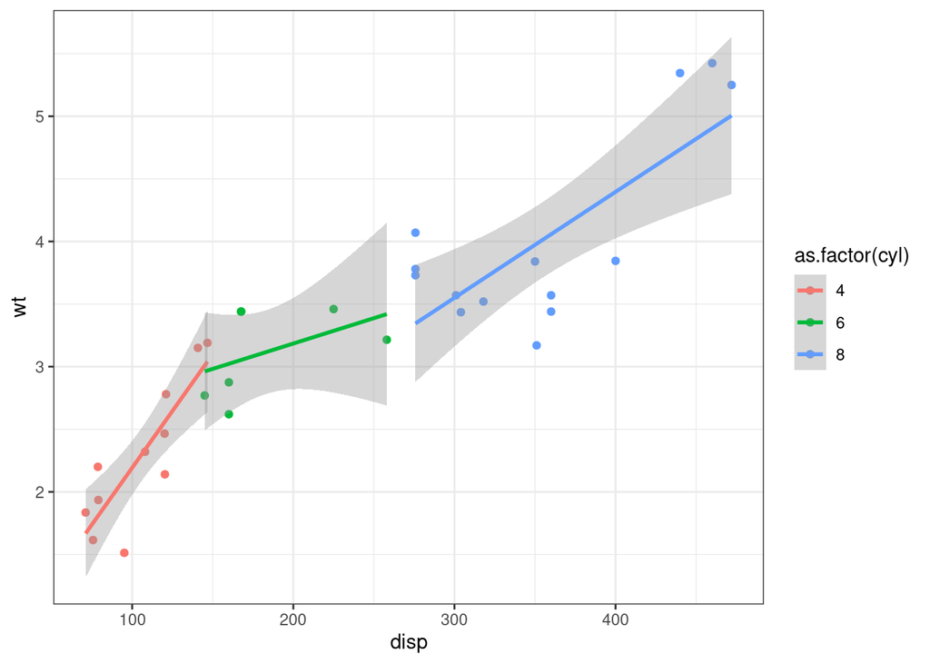

```r
library(ggplot2)
ggplot(data = mtcars, aes(x = disp, y = wt, color = as.factor(cyl))) + geom_point() + theme_bw() +
    geom_smooth(method="lm")
```

# 2 Simulation of G/G/1 queues

This code simulates the behavior of a M/M/1 queue with the FIFO discipline. However, mutatis mutandis, it can be easily changed to simulate the dynamics of a G/G/1 queue with an arbitrary scheduling discipline. The main modificaction compared to the code written last week was to wrap it in a function and have it return a small clean data frame with several interesting statistics.

```r
# set.seed(17); # Set seed for reproducibility
MM1 = function (
  N = 1e4,      # number of jobs to simulate;
  lambda = 0.5, # arrival rate
  mu = 1 # service rate
) {
  Arrival = cumsum(rexp(n=N, rate = lambda)); # Arrival times
  Service = rexp(N,rate=1/mu); # Service times
  Remaining = rep(N, x=NA);    # Remaining service times of each job
  Completion = rep(N, x=NA);   # Completion time of each job

  t = 0; # simulation time

  CurrentTask = NA;
  NextArrival = 1;
  while (TRUE) {
    # print(t);
    # print(Arrival);
    # print(Service);
    # print(Remaining);
    dtA = NA;
    dtC = NA;
    if(length(Arrival[Arrival>t])>0) { # if an arrival exists after t
      dtA = head(Arrival[Arrival>t],n=1)-t ; # time to next arrival
    }
    if(!is.na(CurrentTask)) { # if a task is running
      dtC = Remaining[CurrentTask]; # time to next completion
    }
    if(is.na(dtA) & is.na(dtC)) {
      break;
    }

    dt = min(dtA,dtC,na.rm=T);

    # update system variables
    t = t + dt;
    if((NextArrival <=N) & (Arrival[NextArrival] == t)) {
      Remaining[NextArrival] = Service[NextArrival];
      NextArrival = NextArrival + 1;
    }
    if(!is.na(CurrentTask)) {
      Remaining[CurrentTask] = Remaining[CurrentTask] - dt ;
      if(Remaining[CurrentTask] <= 0) {
        Completion[CurrentTask] = t;
        Remaining[CurrentTask] = NA;
      }
      CurrentTask = NA;
    }
    # FIFO scheduling discipline. Change here to implement other scheduling disciplines
    WaitingList=(1:NextArrival)[!is.na(Remaining)]; # Optimize this line!
    if(length(WaitingList)>0) {
      CurrentTask = head(WaitingList,n=1);
    }
  }

  return(data.frame(lambda = lambda , N=N, R_mean = mean(Completion-Arrival),
                    R_sd = sd(Completion-Arrival)))
}

# Make a plot of the ResponseTime as a function of lambda.
MM1(N=100, lambda = 0.1)
```

```
##   lambda   N   R_mean     R_sd
## 1    0.1 100 1.218166 1.205712
```

# 3 Let’s study the behavior of an MM1 Queue

Let’s vary the input rate `lambda`:

```r
df = data.frame()
for(lambda in seq(from=.1, to=.9, by = .1)) {
 df = rbind(df, MM1(N=1000, lambda = lambda))
}
df
```

```
##   lambda    N   R_mean     R_sd
## 1    0.1 1000       NA       NA
## 2    0.2 1000 1.310220 1.335794
## 3    0.3 1000 1.435623 1.425146
## 4    0.4 1000 1.723550 1.673914
## 5    0.5 1000 1.896289 1.792656
## 6    0.6 1000 2.545263 2.167394
## 7    0.7 1000 3.078166 3.420577
## 8    0.8 1000 6.025658 5.492323
## 9    0.9 1000 5.709785 3.889572
```

Now, let’s plot the response time as a function of the load

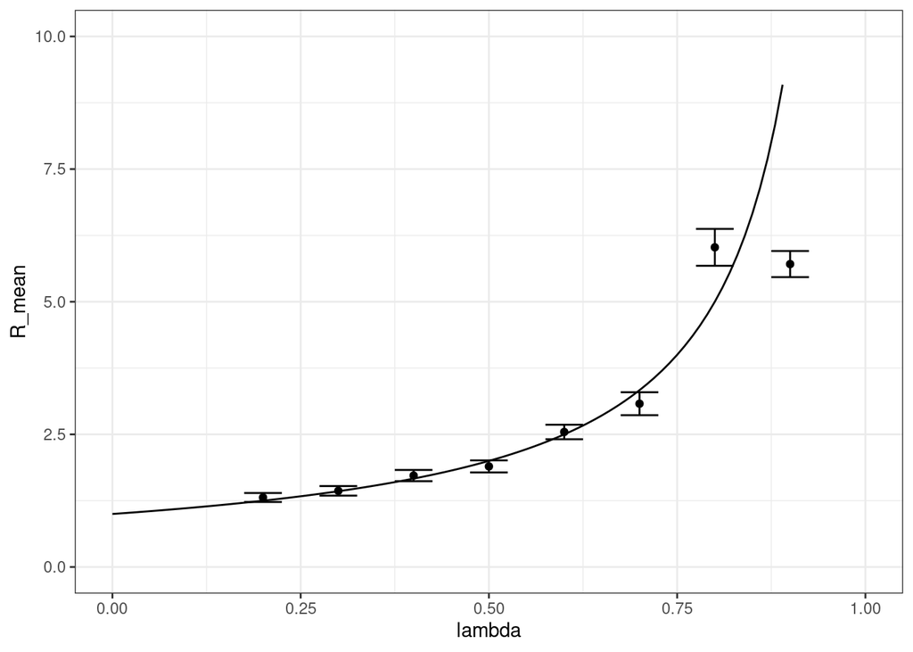

```r
ggplot(data=df, aes(x = lambda, y = R_mean)) + geom_point() +
  geom_errorbar(aes(ymin = R_mean-2*R_sd/sqrt(N), ymax = R_mean+2*R_sd/sqrt(N)),width=.05) +
  xlim(0,1) + ylim(0,10) + geom_function(fun = function(x) 1/(1-x))+
  theme_bw() # + geom_smooth(se = F)
```

Note: if the `geom_function` is not available, you may have to plot it manually, e.g., as follows

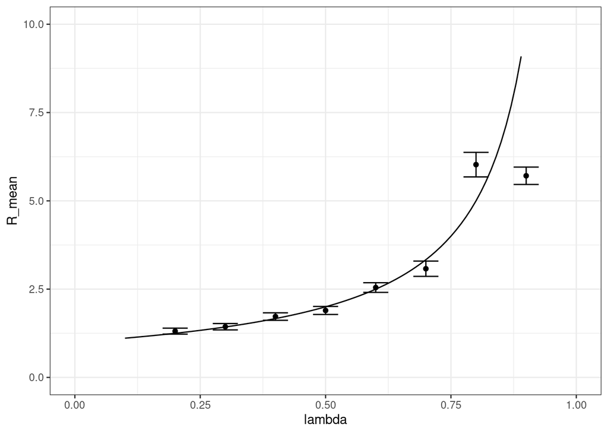

```r
df_th = data.frame(lambda = seq(from=.1, to=.9, by = .01))
df_th$R_mean = 1/(1-df_th$lambda)

ggplot(data=df, aes(x = lambda, y = R_mean)) + geom_point() +
  geom_errorbar(aes(ymin = R_mean-2*R_sd/sqrt(N), ymax = R_mean+2*R_sd/sqrt(N)),width=.05) +
  xlim(0,1) + ylim(0,10) + geom_line(data=df_th) +
  theme_bw() # + geom_smooth(se = F)
```

# 4 TODO for 4th of March

- Modify the MM1 function to allow the service time to follow a $U(0.5, 1.5)$ distribution or a [Gamma distribution](https://en.wikipedia.org/wiki/Gamma_distribution) with parameters $\alpha =\beta = .2$ (so that the expected duration is 1 but the variance is 5).
  - Plot the three behaviors on the same graph with a different color for each graph (Hint: adding the information on the distribution in a column of the dataframe is a good idea…).
  - Comment the behavior. Is it expected ?
- Change the FIFO strategy for a SPT strategy (shortest processing time first) assuming the duration is available to the scheduler when a task enters the system. Compare with the previous results.

Note that, as we explained during the lecture: 1. The estimation of the confidence intervals is incorrect (way over-confident optimistic for large $\lambda$) as the response time of the jobs are not independant from each others. You may want to fix this. 2. The higher the load ($\lambda$), the larger the variance, hence the harder to obtain a good estimation of the response time. Take this into account to adapt the duration of your simulations.

What I care about is not just *clean code* but also *clear explanations*. Indeed, as Harold Abelson wrote in *Structure and Interpretation of Computer Programs*:

> Programs must be written for people to read, and only incidentally for machines to execute.

You will return me both the `Rmd` and the `html` output by sending them both to `arnaud.legrand@imag.fr,jonatha.anselmi@inria.fr,louis-sebastien.rebuffi@inria.fr` before the 4th of March 2022 10PM.